# TO404 Homework Assignment 2

Richard Einhorn

Due Sun Nov 08, 2020 11:59PM

# 1 Setup

## 1.1 Import Libraries

## 1.2 Create Dataset

```r
filenames <- list.files("data", pattern="*.csv")
base_data <- read.csv('data/201901-citibike-tripdata.csv')

for (file in filenames[2:12]) {
  file_path = paste("data/", file, sep='')
  base_data <- rbind(base_data, read.csv(file_path))
}
```

## 1.3 Create subset for analysis and visualization

```r
set.seed(1234)
n = trunc(0.05 * nrow(base_data))
test_id <- sample(1:nrow(base_data), n)
base_data <- base_data[test_id,]
write.csv(base_data, "subset.csv")
```

## 1.4 Clean and Prepare Dataset

```r
# column-wise summary of dataset and summary statistics
summary(base_data)
```

```
##   tripduration        starttime           stoptime         start.station.id
##  Min.   :     61.0   Length:1027584     Length:1027584     Length:1027584
##  1st Qu.:    362.0   Class :character   Class :character   Class :character
##  Median :    615.0   Mode  :character   Mode  :character   Mode  :character
##  Mean   :    992.4
##  3rd Qu.:   1078.0
##  Max.   :2946638.0
##  start.station.name start.station.latitude start.station.longitude
##  Length:1027584     Min.   :40.66          Min.   :-74.03
##  Class :character   1st Qu.:40.72          1st Qu.:-74.00
##  Mode  :character   Median :40.74          Median :-73.99
##                     Mean   :40.74          Mean   :-73.98
##                     3rd Qu.:40.76          3rd Qu.:-73.97
##                     Max.   :40.86          Max.   :-73.89
##  end.station.id     end.station.name   end.station.latitude
##  Length:1027584     Length:1027584     Min.   :40.66
##  Class :character   Class :character   1st Qu.:40.72
##  Mode  :character   Mode  :character   Median :40.74
##                                        Mean   :40.74
##                                        3rd Qu.:40.76
##                                        Max.   :40.86
##  end.station.longitude     bikeid        usertype           birth.year
##  Min.   :-74.05        Min.   :14529   Length:1027584     Min.   :1885
##  1st Qu.:-74.00        1st Qu.:25364   Class :character   1st Qu.:1970
##  Median :-73.99        Median :30930   Mode  :character   Median :1983
##  Mean   :-73.98        Mean   :29689                      Mean   :1980
##  3rd Qu.:-73.97        3rd Qu.:35051                      3rd Qu.:1990
##  Max.   :-73.88        Max.   :42046                      Max.   :2003
##      gender
##  Min.   :0.000
##  1st Qu.:1.000
##  Median :1.000
##  Mean   :1.165
##  3rd Qu.:1.000
##  Max.   :2.000
```

```r
# check for NAs
sapply(base_data, function(x) sum(is.na(x)))
```

```
##            tripduration               starttime                stoptime
##                       0                       0                       0
##        start.station.id      start.station.name  start.station.latitude
##                       0                       0                       0
## start.station.longitude          end.station.id        end.station.name
##                       0                       0                       0
##    end.station.latitude   end.station.longitude                  bikeid
##                       0                       0                       0
##                usertype              birth.year                  gender
##                       0                       0                       0
```

```r
# change tripduration units to minutes
base_data <- base_data %>%
  mutate(tripduration = tripduration/60)

# converting starttime and stoptime to datetime values (function processing time monitored for reference)
timezone = "America/New_York"
ptm <- proc.time()
base_data <- base_data %>%
  mutate(
    starttime = fast_strptime(starttime, format = "%Y-%m-%d %H:%M:%OS", tz=timezone),
    stoptime = fast_strptime(stoptime, format = "%Y-%m-%d %H:%M:%OS", tz=timezone)
    )
proc.time() - ptm
```

```
##    user  system elapsed
##    1.06    0.02    1.16
```

```r
clean_data <- base_data
```

We see that the data is of high quality - there is almost no missing data, the data in the columns have a consistent format and only a few tweaks are necessary to prepare the data set for further analysis and visualization.

# 2 Understand the Data: Exploratory Data Analysis and Visualisation

## 2.1 Understanding City Bike Users

### 2.1.1 Users: User Type

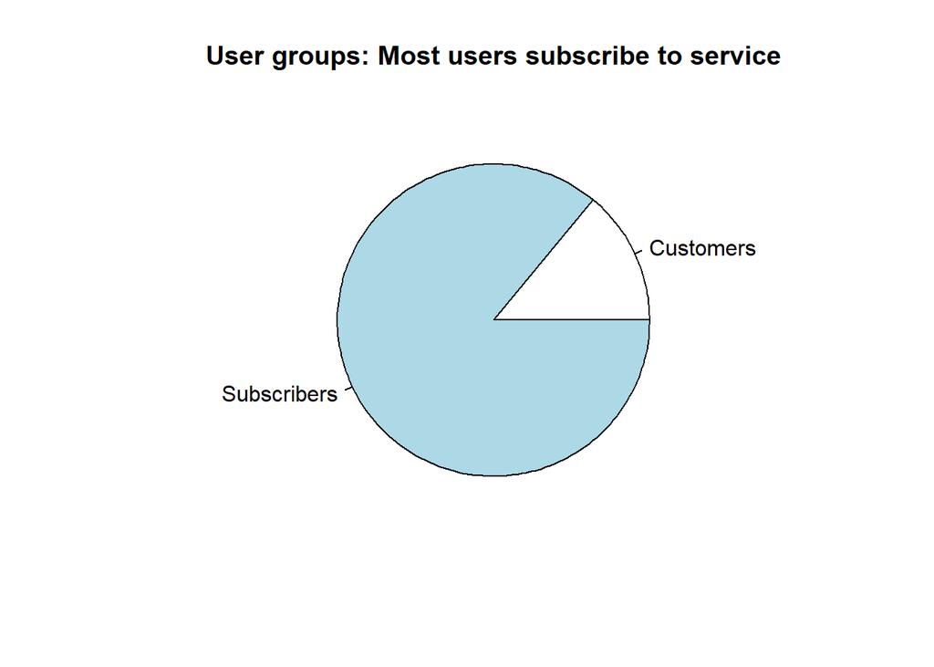

```r
# user type (24h/3d pass vs annual subscriber)
user.types <- unique(clean_data$usertype)
clean_data$usertype <- as.factor(clean_data$usertype)  # convert to 2-level factor
user.shares <- prop.table(table(clean_data$usertype))

pie(user.shares, labels = c("Customers", "Subscribers"), main = "User groups: Most users subscribe to service")
```

*Comment:* Most users buy annual memberships for Citibikes instead of 24-hour or 3-day passes. This is surprising because one could have assumed that the bicycle sharing offer would be most relevant for occasional cyclists or tourists who do not want to purchase a bike for themselves. Instead, it seems that many New Yorkers use the bikes on a regular basis so that it makes sense for them to purchase annual memberships.

### 2.1.2 Users: User Gender

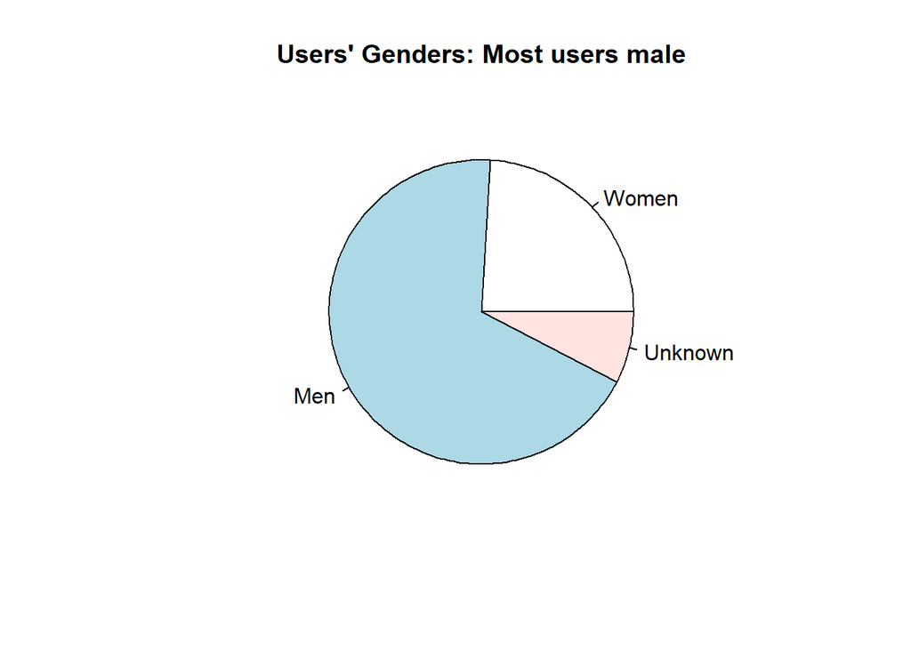

```r
# gender
clean_data <- clean_data %>%
  mutate(gender = ifelse(gender == 0, "unknown", ifelse(gender == 1, "male", "female")))
clean_data$gender <- as.factor(clean_data$gender)  # convert to 3-level factor
users.gender <- prop.table(table(clean_data$gender))

pie(users.gender, labels = c("Women", "Men", "Unknown"), main = "Users' Genders: Most users male")
```

*Comment:* It is surprising that a vast majority of users are male: men made approx. 14.5 million of the total 20.5 million annual rides recorded in the system.

### 2.1.3 Users: User Age

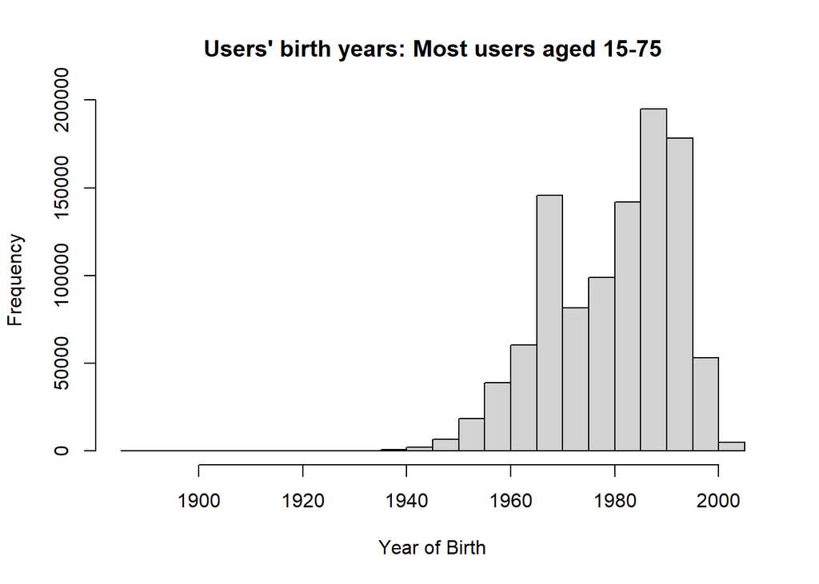

```r
# birth year
hist(clean_data$birth.year, main = "Users' birth years: Most users aged 15-75", xlab = "Year of Birth", ylab = "Frequency")
```

## 2.2 Understanding City Bike Infrastructure

### 2.2.1 Bikes

```r
# bikeid
bikes <- unique(clean_data$bikeid)
paste("Bike count:", length(bikes))
```

```
## [1] "Bike count: 19406"
```

### 2.2.2 Stations

```r
# stations
start.stations <- unique(clean_data$start.station.id)
end.stations <- unique(clean_data$end.station.id)
paste("Delta in end.stations vs start.stations:", length(end.stations) - length(start.stations))
```

```
## [1] "Delta in end.stations vs start.stations: 5"
```

*Comment:* The system has approx. 19,500 bikes with unique ids that circulate between approx. 950 stations. What is interesting to note about the station infrastructure is that there are more end stations than start stations - either some stations are only used as end stations, or stations have been closed, or there is some error in the data.

## 2.3 Understanding City Bike Trips

### 2.3.1 Trip Duration

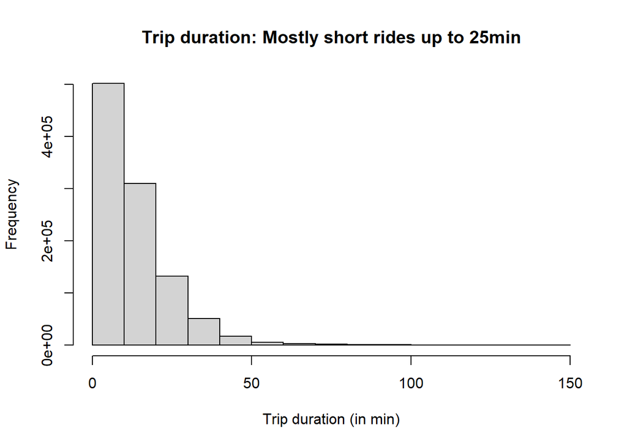

```r
# trip duration (in sec)
hist(clean_data[clean_data$tripduration<150,]$tripduration, main = "Trip duration: Mostly short rides up to 25min", xlab = "Trip duration (in min)")
```

# 3 Identify Patterns in the Ride History Data

## 3.1 Which months are busiest?

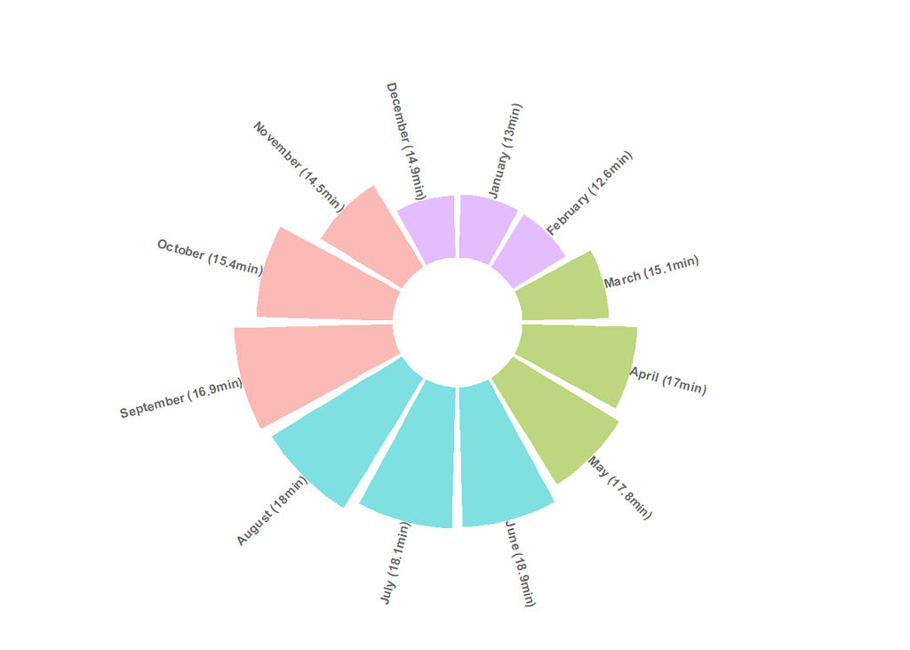

```r
# Circular barplot showing no. trips per month with seasons separated
month_data <- clean_data %>%
  mutate(month = format(starttime, "%m")) %>%
  group_by(month) %>%
  summarise(
    n = n(),
    avg.length = mean(tripduration)
  ) %>%
  mutate(group = c(rep('Winter', 2), rep('Spring', 3), rep('Summer', 3), rep('Fall', 3), 'Winter'))
# add full month names
month_data <- month_data %>%
  arrange(as.numeric(month)) %>%
  mutate(month.str = paste(c("January", "February", "March", "April", "May", "June", "July", "August", "September", "October", "November", "December"), " (", round(month_data$avg.length,1), "min)", sep = ""))

# build chart
margin <- 3
to_add <- data.frame(matrix(NA, margin*nlevels(month_data$group), ncol(month_data)))
colnames(to_add) <- colnames(data)
month_data <- rbind(month_data, to_add)
month_data$id <- seq(1, nrow(month_data))

label_data <- month_data
number_of_bar <- nrow(label_data)
angle <- 90 - 360 * (label_data$id-0.5) / number_of_bar
label_data$hjust <- ifelse( angle < -90, 1, 0)
label_data$angle <- ifelse(angle < -90, angle+180, angle)

g <- ggplot(month_data, aes(x=as.factor(id), y=n, fill=group)) +
  geom_bar(stat="identity", alpha=0.5) +
  ylim(-50000,180000) +
  theme_minimal() +
  theme(
    legend.position = "none",
    axis.text = element_blank(),
    axis.title = element_blank(),
    panel.grid = element_blank(),
    plot.margin = unit(rep(-1,4), "cm")
  ) +
  coord_polar() +
  geom_text(data=label_data, aes(x=id, y=n+10, label=month.str, hjust=hjust), color="black", fontface="bold",alpha=0.6, size=2.5, angle= label_data$angle, inherit.aes = FALSE )

g
```

The above graph allows us to understand bikesharing seasonality. Most trips occur between April and October, with the summer months (blue) generally most attractive to Citibike cyclists. This seasonality is most likely explained by weather and tourist influx. The magnitude of the volatility is significant and provides opportunities for further analysis to predict upper and lower bounds of demand for better capacity planning in any given time of the year.

## 3.2 Which weekdays are busiest?

```r
# prepare data and get weekdays from dates
weekday_data <- clean_data %>%
  mutate(weekday = factor(weekdays(as.Date(starttime)), levels = c("Monday", "Tuesday", "Wednesday", "Thursday", "Friday", "Saturday", "Sunday"))) %>%
  group_by(weekday) %>%
  summarise(
    n = n(),
    avg.length = mean(tripduration)
  ) %>%
  mutate(type = ifelse((weekday == "Saturday" | weekday == "Sunday"), "Weekend", "Weekday"))
```

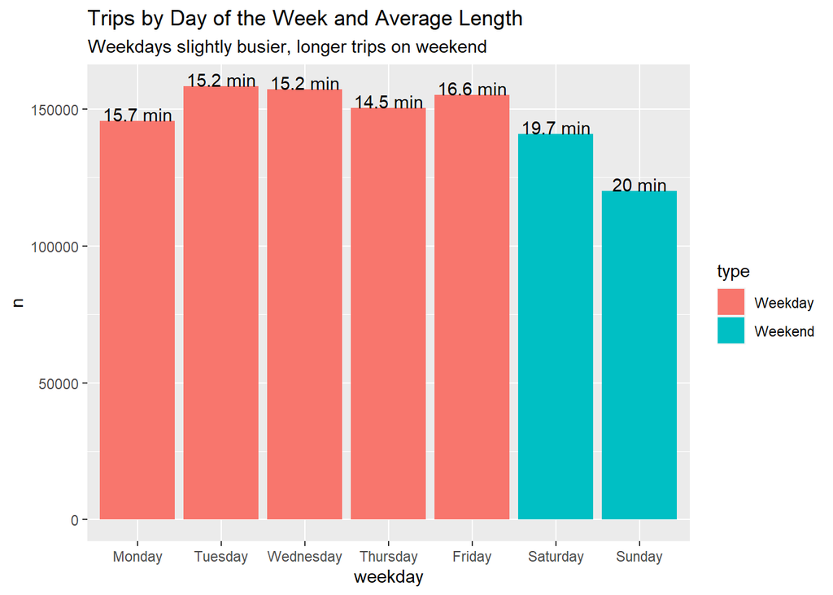

```r
g <- ggplot(weekday_data, aes(x = weekday, y = n, fill = type)) +
  geom_bar(stat="identity") +
  labs(
    title = "Trips by Day of the Week and Average Length",
    subtitle = "Weekdays slightly busier, longer trips on weekend",
    ylab = "Day",
    xlab = "Number of Trips"
  ) +
  geom_text(aes(label=paste(round(avg.length,1), "min"), vjust = 0))

g
```

We can see that usage of Citibikes is spread rather evenly across the week. There seem to be less trips on Mondays and over the weekend (especially on Sundays).

What is interesting to note is that trips on the weekend take approx. 5min longer on average than those during the week, providing evidence that user behavior and ultimately the bikes’ value proposition is different on weekends.

## 3.3 What daytime is busiest?

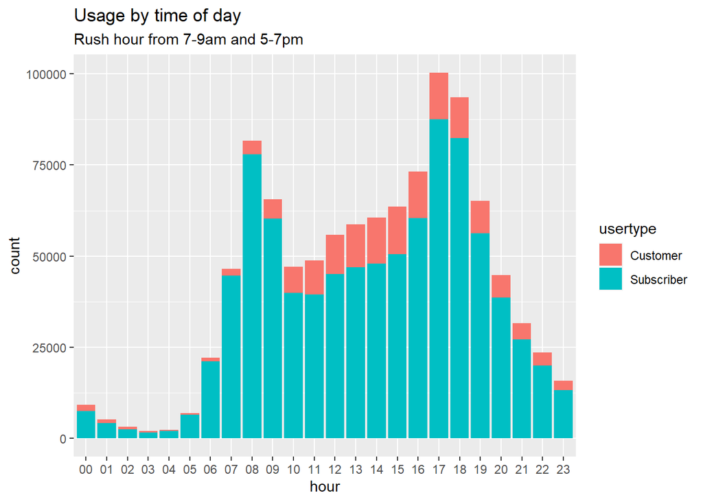

```r
hour_data <- clean_data %>%
  mutate(hour = format(starttime, "%H"), count = 1)

g <- ggplot(hour_data, aes(fill=usertype, y=count, x=hour)) +
  geom_bar(position="stack", stat="identity") +
  labs(
    title = "Usage by time of day",
    subtitle = "Rush hour from 7-9am and 5-7pm",
    xlab = "Time of day",
    ylab = "Number of trips"
  )
g
```

We can see that most trips occur between approx. 6am and 9pm. There is clear evidence that Citibikes are being relied upon by commuters: usage spikes at the usual rush hours between 7-9am and 5-7pm.

Short-term customers purchasing 24-hour or 3-day passes tend to use the bikes during the day, starting from around 10am. This means that heavy utilization rates in the evening rush hour are further increased by short-term customers. This could be a useful insight when considering bike capacities and designing day passes, for example offering discounted day passes valid only outside of rush hours.

## 3.4 When do different age groups use Citibikes?

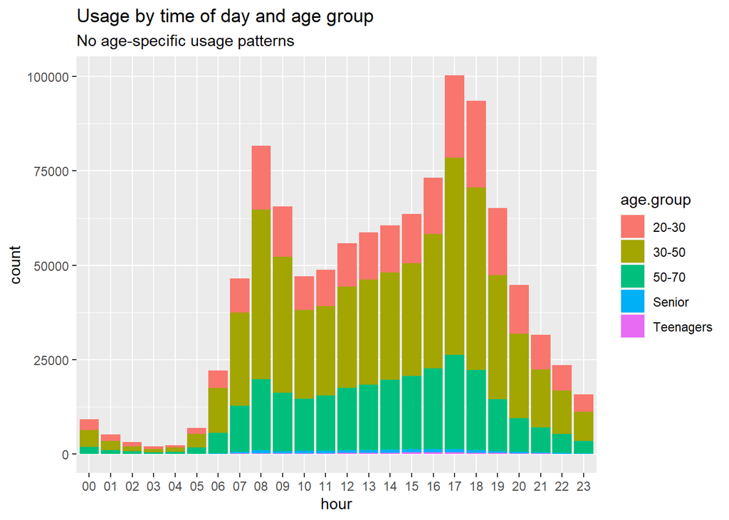

```r
age_group_data <- clean_data %>%
  mutate(
    hour = format(starttime, "%H"),
    count = 1,
    age.group = ifelse(birth.year <= 1950, "Senior", ifelse(birth.year <= 1970, "50-70", ifelse(birth.year <= 1990, "30-50", ifelse(birth.year <= 2000, "20-30", "Teenagers")))))

g <- ggplot(age_group_data, aes(fill=age.group, y=count, x=hour)) +
  geom_bar(position="stack", stat="identity") +
  labs(
    title = "Usage by time of day and age group",
    subtitle = "No age-specific usage patterns",
    xlab = "Time of day",
    ylab = "Number of trips"
  )
g
```